MRC Centre for Global Infectious Disease Analysis, Imperial College London

# COVID-19 Methods and Parameters

## Model Structure

The LMIC reports are generated using an age-structured SEIR model. The developed model is an extension of the model used in our previous report (see [Report 12](https://www.imperial.ac.uk/mrc-global-infectious-disease-analysis/covid-19/report-12-global-impact-covid-19/) and the related [publication](https://science.sciencemag.org/content/early/2020/06/11/science.abc0035)) and the source code for the model can be found at https://github.com/mrc-ide/squire. In this model, the infectious class is divided into different stages reflecting progression through different disease severity pathways. These compartments are:

- S = Susceptibles
- E = Exposed (Latent Infection)
- $I_{Mild}$ = Mild Infections (Not Requiring Hospitalisation) – including asymptomatic infection
- $I_{Case}$ = Infections that will subsequently require hospitalisation
- $I_{Hospital}$ = Hospitalised Infection (Requires General Hospital Bed)
- $I_{ICU}$ = Hospitalised Infection in critical care/ICU (Requires critical care/ICU Bed)
- $I_{Rec}$ = Hospitalised Infection Recovering from critical care/ICU Stay (Requires General Hospital Bed)
- R = Recovered
- D = Dead

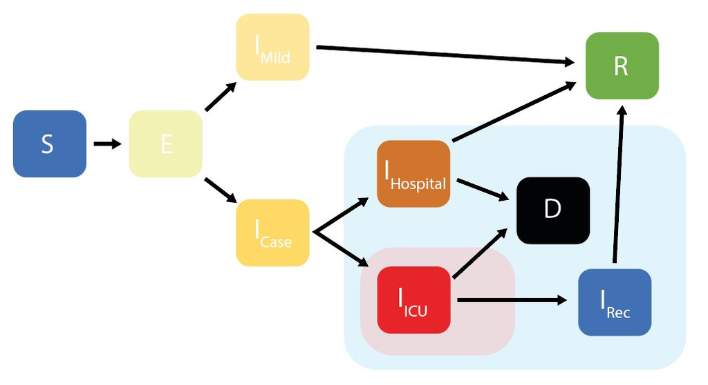

Given initial inputs of hospital/ICU bed capacity and the average time cases spend in hospital, the model dynamically tracks available hospital and ICU beds over time. Individuals newly requiring hospitalisation (either a hospital or ICU bed) are then assigned to either receive care (if the relevant bed is available) or not (if maximum capacity would be exceeded otherwise). Whether or not an individual receives the required care modifies their probability of dying.

In more recent model fitting and scenario projections, we model the roll out of vaccinations. For this work we use the extended version of the above model that was used in our previous reports on vaccination (see [Report 33](https://www.imperial.ac.uk/mrc-global-infectious-disease-analysis/covid-19/report-33-vaccine/) and the related [publication](https://www.sciencedirect.com/science/article/pii/S0264410X21004278)) and the source code for the model can be found at https://github.com/mrc-ide/nimue.

## Interventions

### Version 8

Roll out of global vaccination efforts is modelled. Model fitting uses the extended transmission model, with full model details and parameters used available in [Report 33](https://www.imperial.ac.uk/mrc-global-infectious-disease-analysis/covid-19/report-33-vaccine/) and the related [publication](https://www.sciencedirect.com/science/article/pii/S0264410X21004278). However, to model the specific vaccination roll out in each country, we have had to introduce a number of assumptions about vaccine efficacy, roll-out speed to date, dosing strategy, vaccine hesitancy, vaccine prioritisation and future roll out speed and uptake.

Firstly, vaccine roll out is sourced from both [Our World In Data](https://ourworldindata.org/covid-vaccinations) and the [WHO](https://covid19.who.int/info/). Both sources of data detail information about the number of vaccinations that have been given out and how many second doses have been given out. Our World In Data (OWID) provides vaccination roll out over time and is the preferred data source. However, for many settings the WHO has more recent data on total vaccinations, however, it does not provide historic estimates. We use a simple linear interpolation to estimate the doses between the last date in OWID and the last date updated in the WHO data source (if the WHO data source is more recent than OWID). In a number of countries, we only know total vaccinations given out by a specific date (e.g. we only know that x doses have been administered by y date). In these countries, we assume that all doses were given out over the previous 30 days. We similarly source the number of 1st vs 2nd doses that have been given out in each country using a similar approach, sourcing from both OWID and WHO where appropriate. For forward scenario projections we assume that vaccination roll-out continues at the same speed linearly until all available doses have been given out, which for COVAX countries is doses equal to 20% of the population size and for non-COVAX countries is equal to 98% of the population size. For countries yet to start vaccinating, (exclusively COVAX initiative countries), we assume that doses to achieve 20% of the population being vaccinated will have occurred by December 2021.

Secondly, to calculate vaccine efficacy we model 3 forms of vaccine impact: 1) infection blocking, 2) severe disease blocking (preventing hospitalisation) and 3) reducing onwards infectiousness of vaccinated individuals who become infected. Both 1) and 2) have been shown to be dependent on the vaccine type, number of doses received, the time since first vaccination, the time between first dose and booster dose and the variants of concern in the population. Unfortunately, this information is largely absent for the vast majority of countries. In addition, our compartmental framework used models the vaccinated population as a whole and as such we use a weighting approach, where the mean vaccine efficacy for the population represents the ratio of individuals who have received a first dose more than 14 days ago and those who have received a second dose. We assume that the minimum (all individuals have only received their 1st dose) and maximum (all individuals vaccinated have had both doses) infection blocking efficacy is equal to 60% and 80% respectively. For example, if half the population has received their 2nd dose the assumed population-wide vaccine efficacy against infection would be 70%. In this way we model a changing vaccine efficacy over time as more individuals progress to having received both vaccine doses. For severe disease efficacy, we assume the minimum and maximum efficacy is equal to 80% and 98% respectively. If we do not know from data sources the proportion of individuals who have received a first vs second dose we assume that 28-days after the start of vaccination that half the population has received a second dose, i.e. 70% and 89% efficacy for infection blocking and severe disease blocking respectively. Lastly, we assume that individuals who have been vaccinated have a 50% reduction in infectiousness if infected. These chosen efficacy values broadly reflect the range of estimated efficacies seen in response to wild-type and non-immune escape variants of concern (see [recent SPI-M-O report on UK COVID-19 modelling](https://assets.publishing.service.gov.uk/government/uploads/system/uploads/attachment_data/file/984521/S1227_SPI-M-O_Summary_of_further_modelling_of_easing_restrictions_Roadmap_Step_3__2_.pdf). These values have been purposefully not chosen to reflect a specific vaccine as there are too many unknowns currently over global vaccine roll out (e.g. what vaccine types have been given out in each country, what proportion of each vaccine type has been used, what is their specific dosing strategy and delay between 1st and 2nd dose etc.) We also assume that vaccine protection wanes over a year, which has been chosen to reflect the hypothesised decrease in vaccine efficacy in response to vaccine-escape variants. While unknown if/when such variants will appear, so too is the level of cross-immunity that current vaccines will afford against future variants. As a result long term projections should be interpreted with caution.

With the introduction of vaccination, the same model outputs and summary figures are presented, with $R_eff$ being plotted to now show the decrease in transmission due to both interventions and the increase in immunity resulting from both previous infection and vaccination.

### Version 6

No new model fitting or intervention changes implemented in Version 6. The main changes relate to the parameter update (see Model Parameters section below).

Changes have been made in order to provide scenarios for countries that are yet to document any COVID-19 deaths. These scenarios are noted in the data for that country within the new data column - **death_calibrated** - that describes whether the scenario is the result of model fits calibrated to death data. In countries with no deaths to date, we provide scenario projections of what would happen if 5 imported cases occurred today with no future intervention changes. We assume three different R0s. For our upper estimate, we assume that R0 is equal to the mean R0 of countries in the same income classification (High, Upper Middle, Lower Middle, Low Income). For our lower estimate, we assume that R0 is equal to either 1.2 or the current Rt of countries in the same income classification (whichever is highest). Lastly, our central estimate is half way between the upper and lower estimate. These 3 scenarios are labelled as Relax Interventions 50%, Additional 50% Reduction and Maintain Status Quo in order to maintain consistency with the calibrated scenarios.

### Version 5

We continue the extensions made in version 4, by extending $R_t\sigma$ to consider more flexible mobility independent changes to transmission after $pld$. Starting one week after $pld$ we fit a shift to $R_t$ every 14 days, which is maintained after the 14 day period. In this way we model mobility independent changes to that change every 2 weeks. The last mobility independent change is maintained for the last 4 weeks prior to the current day to reflect our inability to estimate the size of this parameter, $R_t\rho_n$ below, due to the approximate 21 day delay between infection and death. $R_t$ is now given by:,

$$R_{t,i} = R_{0,i} . f(-M_{eff}.(1-M_i(t)) -M_{eff.pld}.(M_i(t) - M_{pld}) - R_t\rho_1 - R_t\rho_2\ \ ... \ -R_t\rho_n)$$
where $R_t\rho_1$ is the first mobility independent change in transmission, which starts 7 days after $pld$, i.e. is equal to 0 before this, and is in effect for the remainder of the simulation. $R_t\rho_2$ is the second mobility independent change in transmission, which starts 21 days after $pld$, i.e. 2 weeks after $R_t\rho_1$. We use strong priors, ($N(0, 0.2)$, where $N$ is the normal distribution with a mean of 0 and a standarad deviation of 0.2) to ensure that where mobility is still informative of transmission (where mobility is increasing transmission is also increasing) it is the mobility parameters that are driving the epidemic trajectory rather than the mobility independent changes in transmission.

### Version 4

We assume that transmission can decouple further from mobility, such that after lockdown transmission can be lower than $R_0$ at 100% mobility:

$$R_{t,i} = R_{0,i} . f(-M_{eff}.(1-M_i(t)) -M_{eff.pld}.(M_i(t) - M_{pld}) - R_t\sigma)$$
where $M_{pld}$ is the mobility at its nadir (at post lockdown date, $pld$) and is only in effect after $pld$ such that when $t <= pld$, $M_{eff.pld} = 0$.

$R_t\sigma$ is a one time signmoidal shift in $R_t$ that occurs over 30 days after post lockdown date to reflect mobility independent changes to transmission resulting from changing behaviour. $R_t\sigma$ is thus equal to 0 prior to $pld$ and is equal to the maximum value of $R_t\sigma$ for all time points more than 30 days after $pld$.

### Version 3

We assume that the impact of mobility on transmission will be different after lockdown ends, with a new $M_{eff}$ parameter, $M_{eff.pld,i}$ estimated for after lockdown, with $R_t$ given by:

$$R_{t,i} = R_{0,i} . f(-M_{eff,i}.(1-M_i(t))),\ when\ t < Post\ Lockdown\ Date$$
$$R_{t,i} = R_{0,i} . f(-M_{eff.pld,i}.(1-M_i(t))),\ when\ t > Post\ Lockdown\ Date$$
where the post lockdown date is inferred as when mobility is at its nadir.

### Version 2

We incorporate interventions using mobility data made publically available from [Google](https://www.google.com/covid19/mobility/), which provides data on movement in each country and includes the percent change in visits to places of interest (Grocery & Pharmacy, Parks, Transit Stations, Retail & Recreation, Residential, and Workplaces). Similar to Version 1, we assume that mobility changes will reduce contacts outside the household, whereas the increase in residential movement will not change household contacts. Consequently, we assume that the change in transmission over time can be summarised by averaging the mobility trends for all categories except for Residential and Parks (in which we assume significant contact events are negligable). Formally, $R_t$ (time varying reproductive number) for country $i$ is given by:

$$R_{t,i} = R_{0,i} . f(-M_{eff,i}.(1-M_i(t)))$$
where $f (x) = 2 exp(x)/(1 + exp(x))$ is twice the inverse logit function. $M_i(t)$ is the average mobility trend at time $t$ (in which 1 represnts 100% mobility (i.e. no change) and 0 represents 0% mobility) and $M_{eff,i}$ is the mobility effect size for country $i$. In countries in which mobility data is not available, we use a Boosted Regression Tree model, trained to government policy data from the [ACAPS Government measures Dataset](https://www.acaps.org/covid19-government-measures-dataset), to predict the change in mobility. In scenario projections going forwards we use the mean of the last 7 days mobility as the assumed mobility in the absence of changs in interventions.

### Version 1

In version 1 of these reports, we incorporated the impact of interventions that have been put in place using data from the [Oxford Coronavirus Government Response Tracker](https://www.bsg.ox.ac.uk/research/research-projects/coronavirus-government-response-tracker). We currently make assumptions about the efficacy of these interventions and so the projections should be interpreted as scenarios rather than predictions. Work is ongoing for version 2 to integrate formal statistical fitting to improve these projections. In summary, school closures are assumed to cause a 10% reduction in contacts. Work closure is assumed to cause 30% reduction in contacts. Banning of public events is assumed to lead to a 5% reduction in contacts while restrictions on movement or a lockdown is not in force. Restrictions of movement is assumed to cause an additional 37.5% reduction in contacts on top of the 40% reduction due to school and work closure, leading to a total 77.5% reduction.

## Model Parameters

The parameter table below summarises the our initial estimates incorporated in the package prior to as of 2021-05-08. These were updated in version 6 in response to new data related to age dependent probabilities of different hospital outcomes and the durations of hospital stay. We will continue to periodically update the parameters as our understanding of the epidemic develops. The new parameters in use for version 6 onwards, included in squire v0.5.1, are as follows:

| **Parameter** | **Value** | **Reference** |
| --- | --- | --- |
| Basic reproductive number, R0 | 3.0 | Estimate from Europe, [Flaxman et al](https://www.nature.com/articles/s41586-020-2405-7) |
| Mean Incubation Period | 4.6 days | Estimated to be 5.1 days ([Linton et al.](https://www.medrxiv.org/content/medrxiv/early/2020/01/28/2020.01.26.20018754.full.pdf); [Li et al.](https://www.nejm.org/doi/full/10.1056/NEJMoa2001316) The l… |
| Generation Time | 6.75 days | Bi et al |
| Mean Duration in I_MILD | 2.1 days | Incorporates 0.5 days of infectiousness prior to symptoms; with parameters below ~95% of all infections are mild. In combination with mean duration in I_CASE this gives a mean generation time as above |
| Mean Duration in I_CASE | 4.5 days | Mean onset-to-admission of 4 days. Values in the literature range from 1.2 to 12 days. Includes 0.5 days of infectiousness prior to symptom onset |
| Mean Duration of Hospitalisation for non-critical Cases (I_HOSP) if survive | 9 days | Median value from five studies ([Sreevalsan-Nair et al.](https://www.medrxiv.org/content/10.1101/2020.04.17.20069724v4), [Haw et al.](https://www.ncbi.nlm.nih.gov/pmc/articles/PMC7506175/), [Hawryluk … |
| Mean Duration of Hospitalisation for non-critical Cases (I_HOSP) if die | 9 days | As above |
| Mean duration of Critical Care (I_ICU) if survive | 14.8 days | Mean duration in ICU of 13.3 days [Pritchard et al.](https://www.medrxiv.org/content/10.1101/2020.07.17.20155218v4.full). Ratio of duration in critical care if die: duration in critical care if surviv… |
| Mean duration of Critical Care (I_ICU) if die | 11.1 days | Mean duration in ICU of 13.3 days [Pritchard et al.](https://www.medrxiv.org/content/10.1101/2020.07.17.20155218v4.full). Ratio of duration in critical care if die: duration in critical care if surviv… |
| Mean duration of Stepdown post ICU (I_Rec) | 3 days | Working assumption based on unpublished UK data |
| Mean duration of hospitalisation if require ICU but do not receive it and die | 1 day | Working assumption |
| Mean duration of hospitalisation if require ICU but do not receive it and survive | 7.4 days | Working assumption (Half duration of ICU and survive) |
| Mean duration of hospitalisation if require Oxygen but do not receive it and die | 4.5 days | Working assumption (Half duration of Oxygen and die) |
| Mean duration of hospitalisation if require Oxygen but do not receive it and survive | 4.5 days | Working assumption (Half duration of Oxygen and survive) |
| Probability of death if require critical care but do not receive it | 95% | Working assumption based on expert clinical opinion |
| Probability of death if require hospitalisation but do not receive it | 60% | Working assumption based on expert clinical opinion |

### Age-Specific Parameters

| **Age-Group** | **Proportion of Infections Hospitalised** | **Proportion of hospitalised cases requiring critical care** | **Proportion of hospital deaths occurring in ICU** | **Proportion of non-critical care cases dying** | **Proportion of critical care cases dying** |
| --- | --- | --- | --- | --- | --- |
| 0 to 4 | 0.001 | 0.181 | 0.8 | 0.013 | 0.227 |
| 5 to 9 | 0.001 | 0.181 | 0.8 | 0.014 | 0.252 |
| 10 to 14 | 0.002 | 0.181 | 0.8 | 0.016 | 0.281 |
| 15 to 19 | 0.002 | 0.137 | 0.8 | 0.016 | 0.413 |
| 20 to 24 | 0.003 | 0.122 | 0.8 | 0.018 | 0.518 |
| 25 to 29 | 0.005 | 0.123 | 0.8 | 0.020 | 0.573 |
| 30 to 34 | 0.007 | 0.136 | 0.8 | 0.023 | 0.576 |
| 35 to 39 | 0.009 | 0.161 | 0.8 | 0.026 | 0.543 |
| 40 to 44 | 0.013 | 0.197 | 0.8 | 0.030 | 0.494 |
| 45 to 49 | 0.018 | 0.242 | 0.8 | 0.036 | 0.447 |
| 50 to 54 | 0.025 | 0.289 | 0.8 | 0.042 | 0.417 |
| 55 to 59 | 0.036 | 0.327 | 0.8 | 0.050 | 0.411 |
| 60 to 64 | 0.050 | 0.337 | 0.8 | 0.056 | 0.443 |
| 65 to 69 | 0.071 | 0.309 | 0.8 | 0.060 | 0.539 |
| 70 to 74 | 0.100 | 0.244 | 0.8 | 0.123 | 0.570 |
| 75 to 79 | 0.140 | 0.160 | 0.8 | 0.184 | 0.643 |
| 80+ | 0.233 | 0.057 | 0.8 | 0.341 | 0.993 |
| Source | [Salje et al.](http://dx.doi.org/10.1126/science.abc3517) | [Salje et al.](http://dx.doi.org/10.1126/science.abc3517) | Assumed | Calculated from IFR in [Report 34](https://www.imperial.ac.uk/mrc-global-infectious-disease-analysis/covid-19/report-34-ifr/) | Calculated from IFR in [Report 34](https://www.imperial.ac.uk/mrc-global-infectious-disease-analysis/covid-19/report-34-ifr/) |

The parameters used in model fits untill 2020-11-11 are detailed below:

| **Parameter** | **Value** | **Reference** |
| --- | --- | --- |
| Basic reproductive number, $R_0$ | 3.0 | [Report 13](https://www.imperial.ac.uk/mrc-global-infectious-disease-analysis/covid-19/report-13-europe-npi-impact/) |
| Mean Incubation Period | 4.6 days | [Report 9](https://www.imperial.ac.uk/mrc-global-infectious-disease-analysis/covid-19/report-9-impact-of-npis-on-covid-19/); [Linton et al.](https://www.medrxiv.org/content/medrxiv/early/2020/01/28/20… |
| Generation Time | 6.75 days | [Report 9](https://www.imperial.ac.uk/mrc-global-infectious-disease-analysis/covid-19/report-9-impact-of-npis-on-covid-19/) |
| Mean Duration in $I_{MILD}$ | 2.1 days | Incorporates 0.5 days of infectiousness prior to symptoms; with parameters below ~95% of all infections are mild. In combination with mean duration in $I_{CASE}$ this gives a mean generation time as a… |
| Mean Duration in $I_{CASE}$ | 4.5 days | Mean onset-to-admission of 4 days from UK data. Includes 0.5 days of infectiousness prior to symptom onset |
| Mean Duration of Hospitalisation for non-critical Cases ($I_{HOSP}$) if survive | 9.5 days | Based on unpublished UK data |
| Mean Duration of Hospitalisation for non-critical Cases ($I_{HOSP}$) if die | 7.6 days | Based on unpublished UK data |
| Mean duration of Critical Care ($I_{ICU}$) if survive | 11.3 days | Based on [UK data](https://www.icnarc.org/Our-Audit/Audits/Cmp/Reports) adjusted for censoring |
| Mean duration of Critical Care ($I_{ICU}$) if die | 10.1 days | Based on [UK data](https://www.icnarc.org/Our-Audit/Audits/Cmp/Reports) |
| Mean duration of Stepdown post ICU ($I_{Rec}$) | 3.4 days | Based on unpublished UK data |
| Mean duration of hospitalisation if require ICU but do not receive it | 1 day | Working assumption |
| Probability of dying in critical care | 50% | Based on [UK data](https://www.icnarc.org/Our-Audit/Audits/Cmp/Reports) |
| Probability of death if require critical care but do not receive it | 95% | Working assumption based on expert clinical opinion* |
| Probability of death if require hospitalisation but do not receive it | 60% | Working assumption based on expert clinical opinion* |
| Multiplier of duration of stay for LIC and LMIC settings compared to HIC | 50% | Working assumption based on expert clinical opinion* |

*N.B. Given the substantially weaker health systems in LIC and LMIC, it is likely that disease outcomes will differ from the UK. The estimates listed above for the key parameters determining the severity outcomes are the result of a rapid expert clinical review. Eight clinical experts with experience both in treating COVID-19 patients in the UK and with previous experience in clinical practice in LIC/LMICs were asked to provide their assessment of severity outcomes in LMICs. Although there was broad consensus on these outcomes, it should be noted that there was also consensus that this is likely to be highly heterogeneous both within and between countries due to other factors that are difficult to quantify and for which data sources do not readily exist as of 2021-05-08.

### Age-Specific Parameters

| **Age-Group** | **Proportion of Infections Hospitalised** | **Proportion of hospitalised cases requiring critical care** | **Proportion of non-critical care cases dying** |
| --- | --- | --- | --- |
| 0 to 4 | 0.001 | 0.050 | 0.013 |
| 5 to 9 | 0.001 | 0.050 | 0.013 |
| 10 to 14 | 0.001 | 0.050 | 0.013 |
| 15 to 19 | 0.002 | 0.050 | 0.013 |
| 20 to 24 | 0.005 | 0.050 | 0.013 |
| 25 to 29 | 0.010 | 0.050 | 0.013 |
| 30 to 34 | 0.016 | 0.050 | 0.013 |
| 35 to 39 | 0.023 | 0.053 | 0.013 |
| 40 to 44 | 0.029 | 0.060 | 0.015 |
| 45 to 49 | 0.039 | 0.075 | 0.019 |
| 50 to 54 | 0.058 | 0.104 | 0.027 |
| 55 to 59 | 0.072 | 0.149 | 0.042 |
| 60 to 64 | 0.102 | 0.224 | 0.069 |
| 65 to 69 | 0.117 | 0.307 | 0.105 |
| 70 to 74 | 0.146 | 0.386 | 0.149 |
| 75 to 79 | 0.177 | 0.461 | 0.203 |
| 80+ | 0.180 | 0.709 | 0.580 |
| Source | Verity et al. 2020 corrected for non-uniform attack rate in China (see [Report 12](https://www.imperial.ac.uk/mrc-global-infectious-disease-analysis/covid-19/report-12-global-impact-covid-19/)) | Adjusted from IFR distributional shape in Verity et al. 2020 to give an overall proportion of cases requiring critical care of ~30% to match [UK data](https://www.icnarc.org/Our-Audit/Audits/Cmp/Repor… | Calculated from IFR in Verity et al. 2020 corrected for non-uniform attack rate in China (see [Report 12](https://www.imperial.ac.uk/mrc-global-infectious-disease-analysis/covid-19/report-12-global-im… |

Copyright © 2020 Imperial College London. MRC Centre for Global Infectious Disease Analysis. All rights reserved.

Funded by the Wellcome Trust and The Department for International Development